# Australian Football League: How to win

## Sport is about *Winning*

Since the story of Moneyball and the Oakland A's became public, sport has begun a data-driven revolution. Elite sport is about winning and commercial success, and both are closely linked. Data analysis is giving teams the competitive edge in elite competition to "control the controllables" and tilt the game in their favour.

This analysis sets out to link Australian Football League (AFL) player performance with team results (game snippet: youtube.com/watch?v=QH188gSGnsk). My core hypothesis is that these links can identify **how to win** matches and **predict match results** for a season.

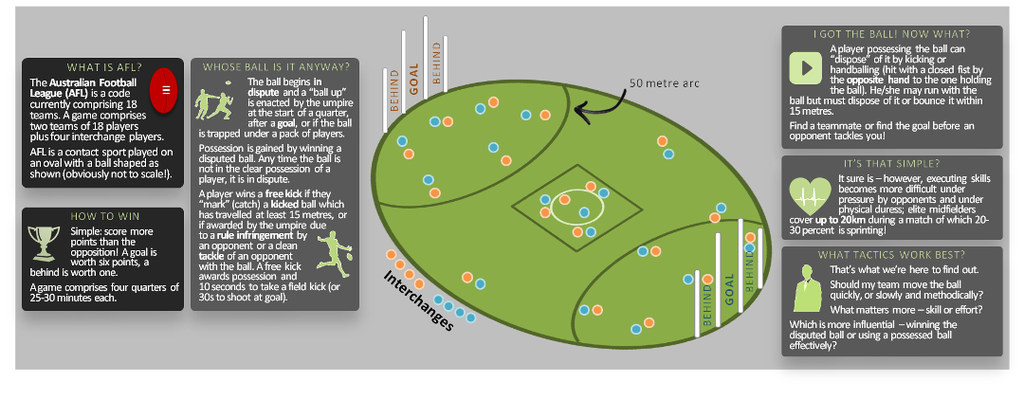

## Data sources and key variables

Data on the most recent 15 AFL seasons have been wrangled into two data frames:

- Player metrics, forming the x variables to be aggregated at team level to explain and predict match results, and
- Team results, the y variable I am seeking to predict.

Detailed steps on scraping and wrangling can be found in this report: rawgit.com/r3nault/Springboard-FDS-Capstone/master/fds-capstone-jameshooi-AFL-020-data-wrangling.html. I have loaded the libraries **dplyr**, **tidyr**, **data.table**, **ggplot2** and **reshape2** to R.

```r
  head(data.frame(player.metrics), 5)
```

```
##             Player     Team Year round Played_pct Behinds Bounces Clangers Clearances Contested_marks Contested_possessions Disposals Frees Frees_against Goal_assists Goals Handballs Hit_outs
## 1     Atkins, Rory Adelaide 2017   R01         82       0       4        2          1               0                     6        19     1             0            2     3         5        0
## 2     Betts, Eddie Adelaide 2017   R01         88       2       2        4          1               0                     4        18     2             3            2     4         4        0
## 3      Brown, Luke Adelaide 2017   R01         86       0       0        0          0               0                     7        18     2             0            0     0         9        0
## 4 Cameron, Charlie Adelaide 2017   R01         84       3       1        4          8               2                    14        23     1             1            0     2         6        0
## 5     Crouch, Matt Adelaide 2017   R01         78       0       1        3          4               0                    15        29     1             0            0     0        20        0
##   Inside_50s Kicks Marks Marks_inside_50 One_pct Tackles Uncontested_possessions
## 1         10    14     5               1       0       7                      14
## 2          7    14     4               3       0       1                      14
## 3          1     9     4               0       5       3                      11
## 4          6    17     4               3       1       6                       9
## 5          2     9     3               0       2       5                      15
```

```r
  head(data.frame(team.results))
```

```
##               Team     score_str final_score round home_away Year match_id rownum      vs_opponent team_result final_margin Q1score_cumul Q2score_cumul Q3score_cumul Q4score_cumul ETscore_cumul
## 1          Carlton   27 46 76 89          89   R01      home 2017     1001      1         Richmond        loss          -43            27            46            76            89            NA
## 2         Richmond 45 83 101 132         132   R01      away 2017     1001      2          Carlton         win           43            45            83           101           132            NA
## 3      Collingwood   11 51 65 86          86   R01      home 2017     1002      3 Western Bulldogs        loss          -14            11            51            65            86            NA
## 4 Western Bulldogs  31 55 90 100         100   R01      away 2017     1002      4      Collingwood         win           14            31            55            90           100            NA
## 5         St Kilda   38 50 63 90          90   R01      home 2017     1003      5        Melbourne        loss          -30            38            50            63            90            NA
## 6        Melbourne  15 58 97 120         120   R01      away 2017     1003      6         St Kilda         win           30            15            58            97           120            NA
##   Q1score Q2score Q3score Q4score ETscore Q1_win Q2_win Q3_win Q4_win ET_win
## 1      27      19      30      13      NA      0      0      1      0     NA
## 2      45      38      18      31      NA      1      1      0      1     NA
## 3      11      40      14      21      NA      0      1      0      1     NA
## 4      31      24      35      10      NA      1      0      1      0     NA
## 5      38      12      13      27      NA      1      0      0      1     NA
## 6      15      43      39      23      NA      0      1      1      0     NA
```

## Player metrics glossary

Here is a set of very brief descriptions of the player metrics tracked during an AFL match:

| Term | Description | Term | Description |
| --- | --- | --- | --- |
| Goal | Kicking the ball through the taller centre posts (6 points) | **Behind** | Ball goes through the shorter side posts or “goal” is touched by a player before crossing the line (1 point) |
| Goal assist | As the name suggests, assisting a teammate’s goal | **Hit out** | Tapping the ball from a "ball up" (umpire bounces or throws ball up for a contest) |
| Disposal | Also called a possession; a kick or handball | **Kick** | Kicking the ball, usually to a team mate or goal |
| Handball | Hit ball with a closed fist when held by opposite hand | **Contested possession** | Winning the ball in a contest and disposing of it |
| Uncontested possession | Receiving or finding the ball in open space and disposing of it | **Clearance** | Clearing a disputed ball to team advantage |
| Mark | Catching a kicked ball which has travelled at least 15m | **Mark inside 50** | A mark taken inside the attacking 50m arc |
| Contested mark | A mark taken against one or more opponents or in a pack of players | **Inside 50** | Getting the ball inside the attacking 50m arc from goal |
| Bounce | Running with the ball, a player must either bounce it or dispose of it within 15m | **Clanger** | An unforced error e.g. dropping an easy mark |
| Tackle | Grabbing the player with the ball between knees and shoulders | **One percenter** | An act which shows extraordinary courage or effort |
| Free kick against | Giving away a free kick to the opposition (being penalised) |  |  |

## Exploratory Analysis

## Explore: Data preparation

A couple of steps are needed to shape data for visualisation. This prepares data by player showing match result:

```r
  AFL.by.player = merge(player.metrics, team.results, by.x = c("Year","round","Team"), by.y = c("Year","round","Team")) %>%
  select(-score_str, -rownum, -(Q1score_cumul:ETscore)) %>%
  mutate(team_result = as.factor(if_else(team_result == "win", 1, 0)),
         Q1_win = as.factor(Q1_win), Q2_win = as.factor(Q2_win), Q3_win = as.factor(Q3_win), Q4_win = as.factor(Q4_win),
         ET_win = as.factor(ET_win), match_score_idx = final_score/(final_score - final_margin)) %>%
  select(-final_score, -final_margin)
  head(AFL.by.player, 3)
```

```
##   Year round     Team          Player Played_pct Behinds Bounces Clangers Clearances Contested_marks Contested_possessions Disposals Frees Frees_against Goal_assists Goals Handballs Hit_outs
## 1 2003   R01 Adelaide Bassett, Nathan         97       0       0        1          1               0                     4         9     1             0            1     0         3        0
## 2 2003   R01 Adelaide   Bickley, Mark         61       0       0        1          3               0                     7        17     1             1            3     0        13        0
## 3 2003   R01 Adelaide Biglands, Rhett         47       1       0        0          0               0                     3         3     1             0            0     0         2        8
##   Inside_50s Kicks Marks Marks_inside_50 One_pct Tackles Uncontested_possessions home_away match_id vs_opponent team_result Q1_win Q2_win Q3_win Q4_win ET_win match_score_idx
## 1          2     6     1               0       2       1                       5      home     3741   Fremantle           1      1      1      1      0   <NA>        1.629213
## 2          3     4     4               1       0       2                      10      home     3741   Fremantle           1      1      1      1      0   <NA>        1.629213
## 3          0     1     1               0       1       0                       1      home     3741   Fremantle           1      1      1      1      0   <NA>        1.629213
```

Then the data needs to be aggregated by team taking the sum of player metrics:

```r
  AFL.by.team = AFL.by.player %>%
  group_by(Year, round, Team, home_away, match_id, vs_opponent, team_result, Q1_win, Q2_win, Q3_win, Q4_win, ET_win, match_score_idx) %>%
  select(-Player, -Played_pct) %>% summarise_all(funs(sum)) %>% ungroup
  head(AFL.by.team, 3)
```

```
## # A tibble: 3 x 33
##    Year round     Team home_away match_id vs_opponent team_result Q1_win Q2_win Q3_win Q4_win ET_win match_score_idx Behinds Bounces Clangers Clearances Contested_marks Contested_possessions
##   <dbl> <chr>    <chr>     <chr>    <dbl>       <chr>      <fctr> <fctr> <fctr> <fctr> <fctr> <fctr>           <dbl>   <dbl>   <dbl>    <dbl>      <dbl>           <dbl>                 <dbl>
## 1  2003   R01 Adelaide      home     3741   Fremantle           1      1      1      1      0   <NA>       1.6292135      12       9       35         38              10                   146
## 2  2003   R01 Brisbane      home     3738    Essendon           1      1      1      1      1   <NA>       1.7049180      18      20       41         33              11                   118
## 3  2003   R01  Carlton      away     3737      Sydney           0      0      0      0      0   <NA>       0.4931507       9       3       42         33              14                   133
## # ... with 14 more variables: Disposals <dbl>, Frees <dbl>, Frees_against <dbl>, Goal_assists <dbl>, Goals <dbl>, Handballs <dbl>, Hit_outs <dbl>, Inside_50s <dbl>, Kicks <dbl>, Marks <dbl>,
## #   Marks_inside_50 <dbl>, One_pct <dbl>, Tackles <dbl>, Uncontested_possessions <dbl>
```

## Explore: Visualising base metrics (pg.1 of 3)

Metrics by year, showing median, IQR and range (Red/LHS = loss or draw, Blue/RHS = win):

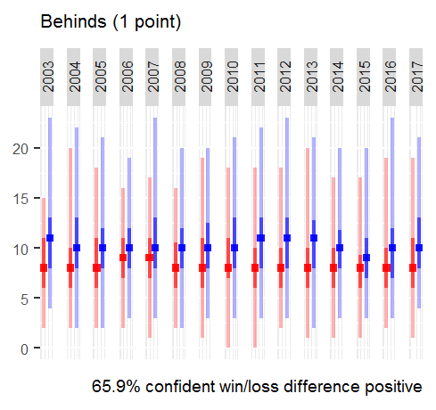

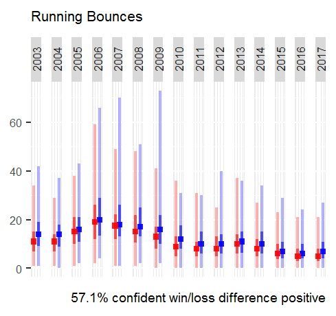

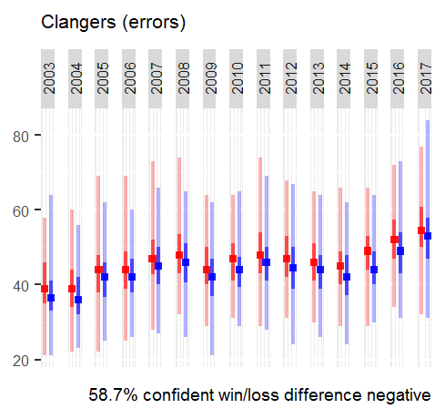

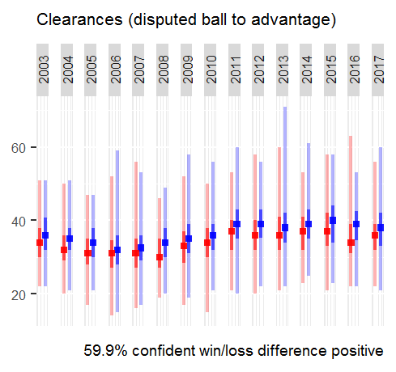

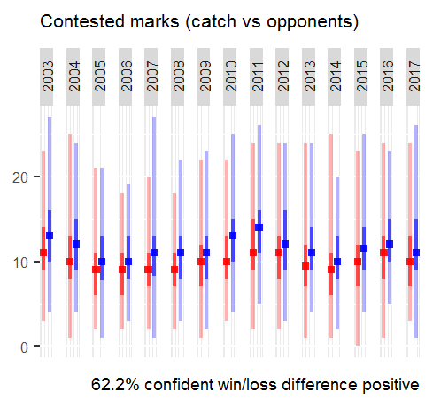

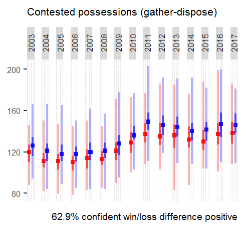

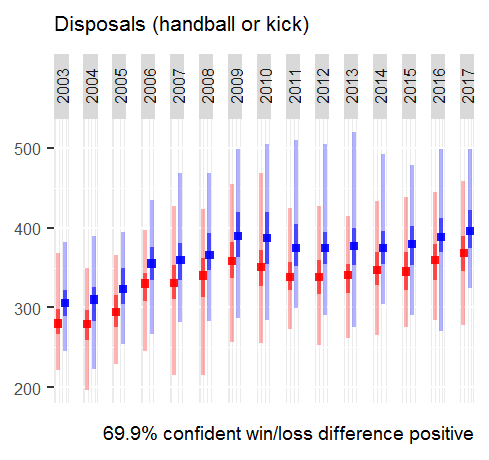

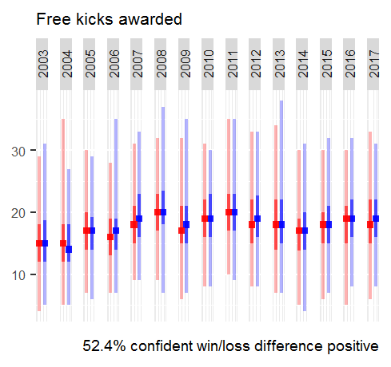

## Explore: Visualising base metrics (pg.2 of 3)

Metrics by year, showing median, IQR and range (Red/LHS = loss or draw, Blue/RHS = win):

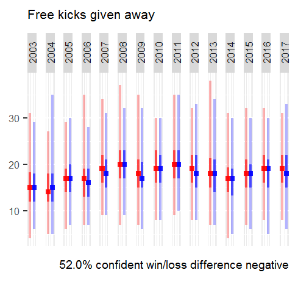

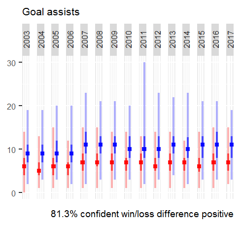

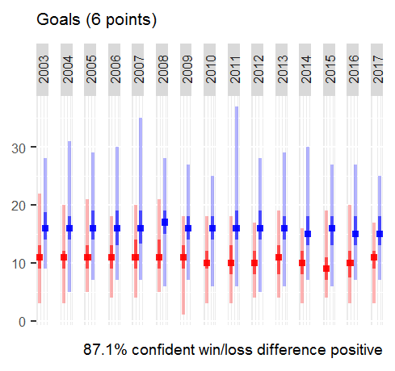

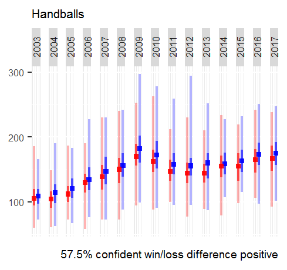

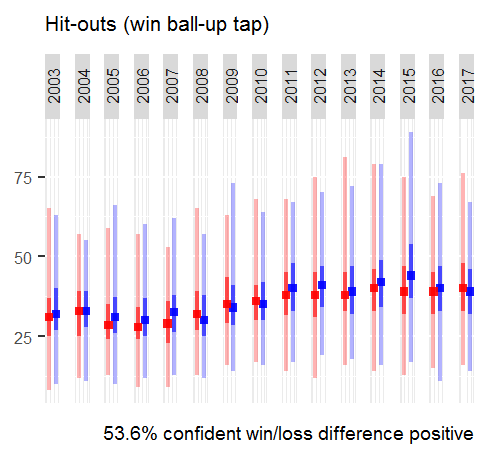

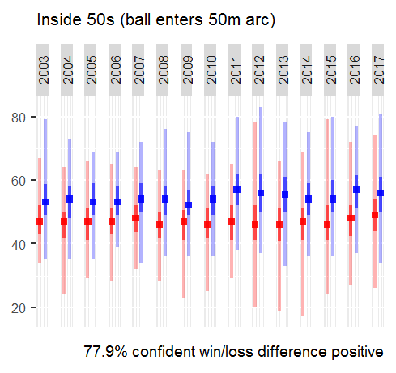

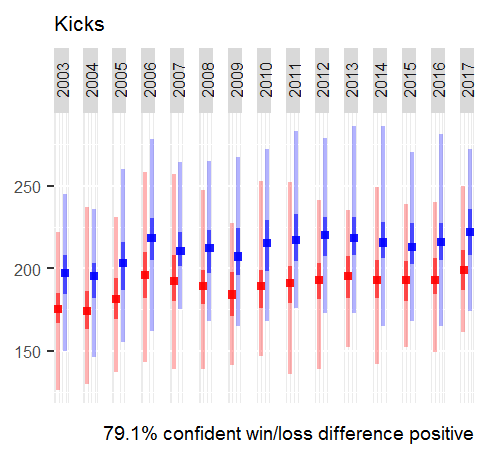

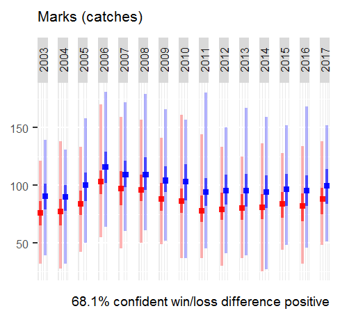

## Explore: Visualising base metrics (pg.3 of 3)

Metrics by year, showing median, IQR and range (Red/LHS = loss or draw, Blue/RHS = win):

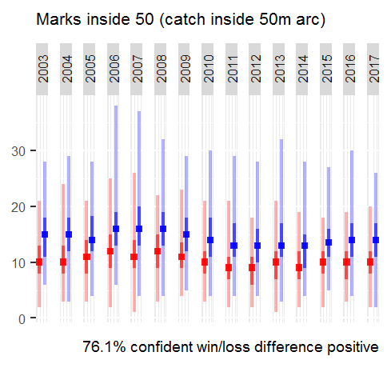

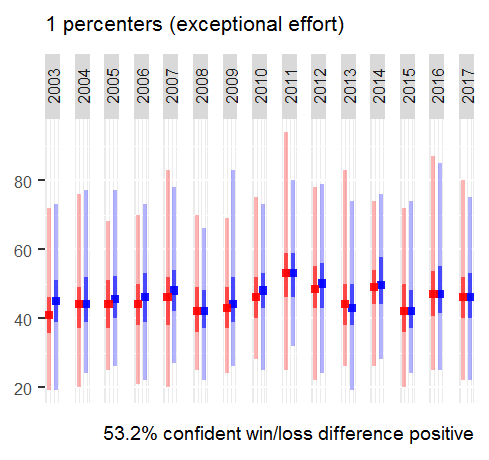

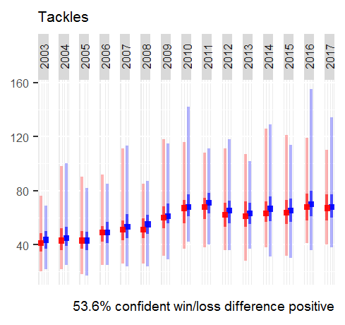

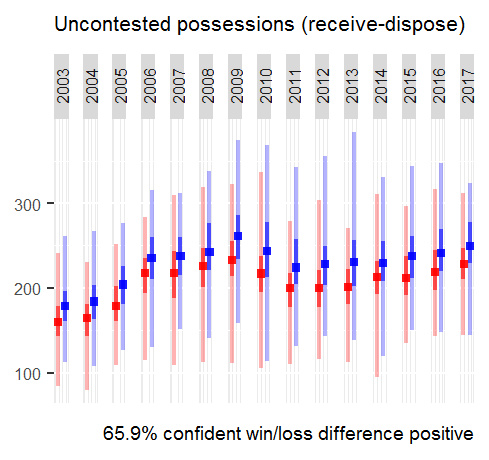

### Insights from base metrics are very limited

Whilst the exploratory analysis highlights some relationships in team-aggregated player metrics, these do not generate usable insights for an AFL team manager or coach. Applying basic game principles, the ability to win is predicated on scoring (measured by Behinds, Goal assists, Goals, Inside 50s, Marks inside 50) which in turn requires the team to possess the ball (measured by Clangers [negator], Disposals, Kicks, Marks, Uncontested possessions). To possess the ball, the team must first win it (Clearances, Contested marks, Contested possessions).

Deeper insights are needed.

## Indices & Statistical Analysis

## Analysis: Sport is adversarial

In analysing AFL team performance, it is important to remember the game is adversarial; i.e. player and team outcomes are impacted by the actions of opponents. This provides a vital lense to two key points: 1) the variability in a team's aggregated metrics due to changes in weather conditions etc can be ignored by performing comparisons with the opposing team (in theory, equally impacted by the same conditions), and 2) insight can only truly be gained by considering team metrics in an adversarial context rather than in isolation.

The below code brings in the opposing team's aggregated metrics for each match (some metrics removed as not used further):

```r
# Match-wise (adversarial) view of results
  AFL.by.team.sub = AFL.by.team %>% select(-Disposals, -Frees, -Hit_outs)
  AFL.by.match = merge(AFL.by.team.sub, AFL.by.team.sub %>% rename (Team.opp = Team),
                        by.x = c("Year","round","match_id","Team"), by.y = c("Year","round","match_id","vs_opponent"),
                        suffixes = c("",".opp")) %>% select(-vs_opponent) %>% arrange(match_id)

  head(AFL.by.match, 4)
```

```
##   Year round match_id             Team home_away team_result Q1_win Q2_win Q3_win Q4_win ET_win match_score_idx Behinds Bounces Clangers Clearances Contested_marks Contested_possessions Frees_against
## 1 2017   R01     1001          Carlton      home           0      0      0      1      0   <NA>       0.6742424       4       8       49         38              14                   138            12
## 2 2017   R01     1001         Richmond      away           1      1      1      0      1   <NA>       1.4831461       9       3       55         40              11                   149            25
## 3 2017   R01     1002      Collingwood      home           0      0      1      0      1   <NA>       0.8600000      11       2       45         42              12                   161            16
## 4 2017   R01     1002 Western Bulldogs      away           1      1      0      1      0   <NA>       1.1627907       6       3       44         26              12                   135            17
##   Goal_assists Goals Handballs Inside_50s Kicks Marks Marks_inside_50 One_pct Tackles Uncontested_possessions         Team.opp home_away.opp team_result.opp Q1_win.opp Q2_win.opp Q3_win.opp
## 1            8    14       133         48   215    99              15      55      67                     203         Richmond          away               1          1          1          0
## 2           13    20       152         61   200    65              16      33      87                     205          Carlton          home               0          0          0          1
## 3            8    12       185         61   246   118              13      43      67                     276 Western Bulldogs          away               1          1          0          1
## 4           10    15       164         44   228   108               9      62      87                     259      Collingwood          home               0          0          1          0
##   Q4_win.opp ET_win.opp match_score_idx.opp Behinds.opp Bounces.opp Clangers.opp Clearances.opp Contested_marks.opp Contested_possessions.opp Frees_against.opp Goal_assists.opp Goals.opp
## 1          1       <NA>           1.4831461           9           3           55             40                  11                       149                25               13        20
## 2          0       <NA>           0.6742424           4           8           49             38                  14                       138                12                8        14
## 3          0       <NA>           1.1627907           6           3           44             26                  12                       135                17               10        15
## 4          1       <NA>           0.8600000          11           2           45             42                  12                       161                16                8        12
##   Handballs.opp Inside_50s.opp Kicks.opp Marks.opp Marks_inside_50.opp One_pct.opp Tackles.opp Uncontested_possessions.opp
## 1           152             61       200        65                  16          33          87                         205
## 2           133             48       215        99                  15          55          67                         203
## 3           164             44       228       108                   9          62          87                         259
## 4           185             61       246       118                  13          43          67                         276
```

## Analysis: Sport is adversarial (cont'd)

Using some basic game knowledge, I created indices to compare team performance versus their match opposition. These were:

| Description | Calculation |
| --- | --- |
| Win the ball in contested situations | \(idx.win.ground.ball = \log(contested.possessions/Opp.contested.possessions)\) |
| Mark the ball in contested situations | \(idx.win.aerial.ball = \log(contested.marks/Opp.contested.marks)\) |
| Win first use from scrimmage | \(idx.clear.ball = \log(clearances/Opp.clearances)\) |
| Make less errors than opposition | \(idx.less.clangers = \log(Opp.clangers/clangers)\) |
| Teamwork for goal | \(idx.goal.assist = \log[(goal.assists/goals)/(Opp.goal.assists/Opp.goals)]\) |
| Maintain clear possession | \(idx.mark.kick = \log[(marks/kicks)/(Opp.marks/Opp.kicks)]\) |
| Accurate 50m entries | \(idx.50m.entry = \log[(marks.inside.50/inside.50s)/(Opp.marks.inside.50/Opp.inside.50s)]\) |
| Work hard when not in possession | \(idx.tackle = \log(tackles/Opp.tackles)\) |
| Win one-percenters | \(idx.one.pct = \log(one.pct/Opp.one.pct)\), and |
| Give away less penalties than opposition | \(idx.less.frees = \log(Opp.frees.against/frees.against)\) |

Note: there were three pairs of 0:Inf in the data which were changed to 0.01:1 prior to applying log. Draws were filtered out.

```
##   Year round match_id             Team home_away team_result Q1_win Q2_win Q3_win Q4_win ET_win match_score_idx         Team.opp match_score_idx.opp idx_win_ground_ball idx_win_aerial_ball
## 1 2017   R01     1001          Carlton      home           0      0      0      1      0   <NA>       0.6742424         Richmond           1.4831461         -0.03330718           0.1047354
## 2 2017   R01     1001         Richmond      away           1      1      1      0      1   <NA>       1.4831461          Carlton           0.6742424          0.03330718          -0.1047354
## 3 2017   R01     1002      Collingwood      home           0      0      1      0      1   <NA>       0.8600000 Western Bulldogs           1.1627907          0.07649211           0.0000000
## 4 2017   R01     1002 Western Bulldogs      away           1      1      0      1      0   <NA>       1.1627907      Collingwood           0.8600000         -0.07649211           0.0000000
## 5 2017   R01     1003        Melbourne      away           1      0      1      1      0   <NA>       1.3333333         St Kilda           0.7500000          0.02430253           0.0000000
## 6 2017   R01     1003         St Kilda      home           0      1      0      0      1   <NA>       0.7500000        Melbourne           1.3333333         -0.02430253           0.0000000
##   idx_clear_ball idx_less_clangers idx_goal_assist idx_mark_kick idx_50m_entry  idx_tackle idx_one_pct idx_less_frees
## 1    -0.02227639       0.050166609     -0.05595141   0.151313374    0.07605987 -0.11344445  0.22184875     0.31875876
## 2     0.02227639      -0.050166609      0.05595141  -0.151313374   -0.07605987  0.11344445 -0.22184875    -0.31875876
## 3     0.20827594      -0.009759837      0.00000000   0.005457992    0.01782368 -0.11344445 -0.15892323     0.02632894
## 4    -0.20827594       0.009759837      0.00000000  -0.005457992   -0.01782368  0.11344445  0.15892323    -0.02632894
## 5     0.15209098      -0.070581074      0.23888209   0.130037988    0.12355469  0.06105397  0.07169322    -0.12493874
## 6    -0.15209098       0.070581074     -0.23888209  -0.130037988   -0.12355469 -0.06105397 -0.07169322     0.12493874
```

## Analysis: Visualising indices (pg.1 of 6)

Plotting indices by year, showing median, IQR and range (Red/LHS = loss, Blue/RHS = win), corresponding mosaic plot coloured by Chi-squared residual:

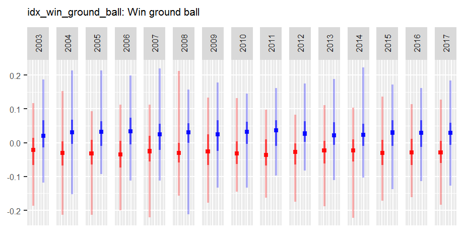

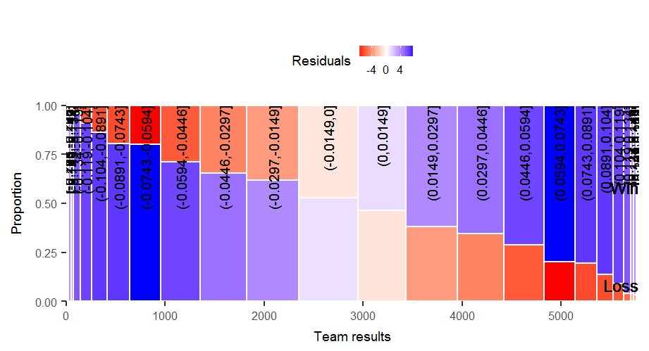

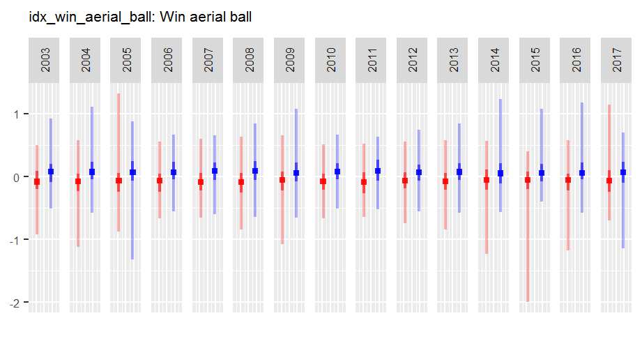

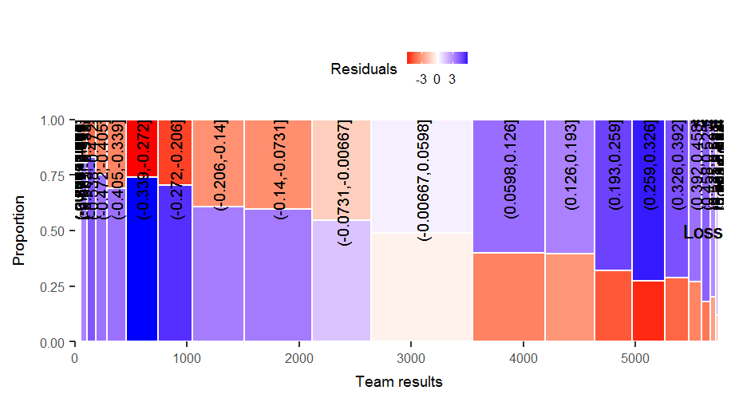

## Analysis: Visualising indices (pg.2 of 6)

Indices by year, showing median, IQR and range (Red/LHS = loss, Blue/RHS = win), corresponding mosaic plot coloured by Chi-squared residual:

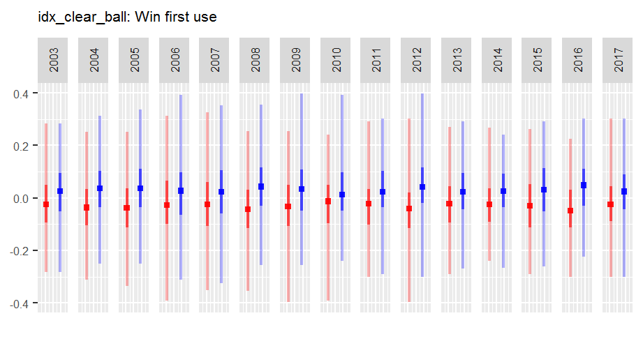

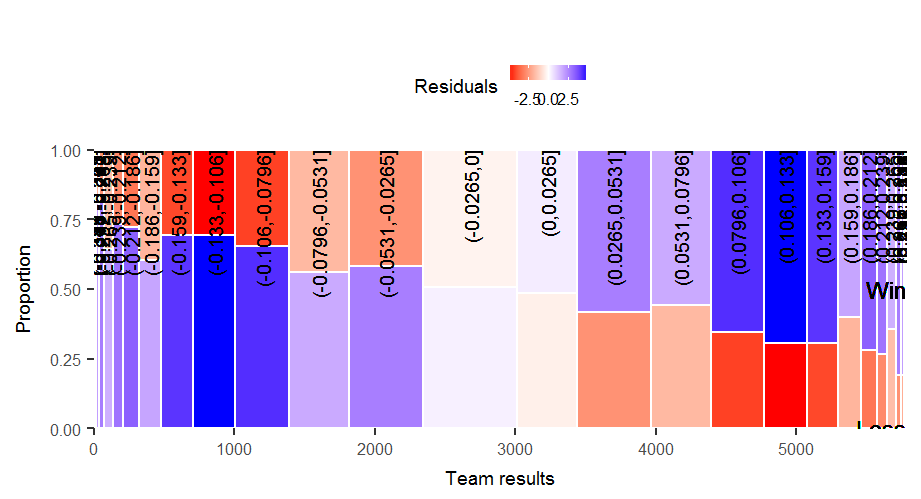

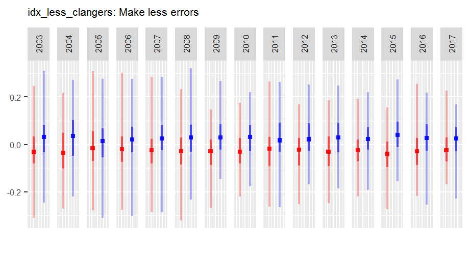

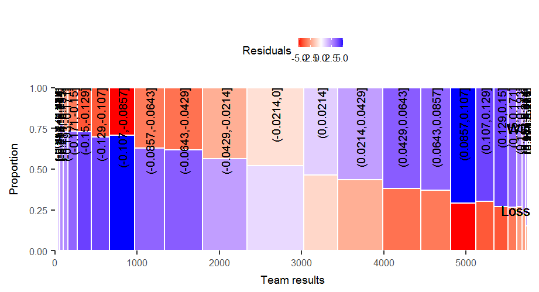